## [DRAFT] Carpentries Pre- and Post-Workshop Assessment Results

June 2018

The Carpentries Assessment Team releases short and long-term assessment results twice per year in June and January. The following results include analyses from both Data Carpentry and Software Carpentry’s pre- and post-workshop surveys.

### Data Carpentry (Pre-Workshop)

# Demographics: Workshop Location

Data Carpentry learners are asked what country their workshop is held.

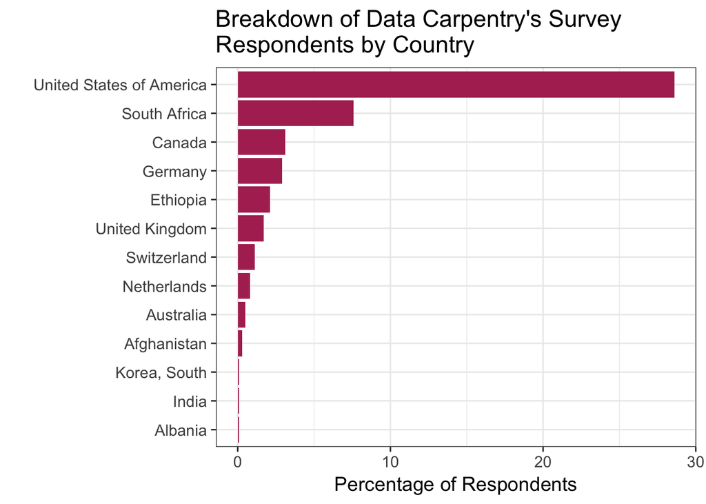

# Demographics: Domain of Research/Work/Study

| Data Carpentry’s Respondents by Discipline | n | % |
| --- | --- | --- |
| Life Sciences | 189 | 19.9 |
| Agricultural or Environmental Sciences | 165 | 17.3 |
| Bioinformatics/Genomics | 106 | 11.1 |
| Biomedical/Health Sciences | 103 | 10.8 |
| Social Sciences | 70 | 7.4 |
| Engineering | 64 | 6.7 |
| Mathematics or Statistics | 56 | 5.9 |
| Computer Science | 47 | 4.9 |
| Earth Sciences | 43 | 4.5 |
| Business/Economics | 36 | 3.8 |
| Humanities | 33 | 3.5 |
| Library Sciences | 22 | 2.3 |
| Physical Sciences | 18 | 1.9 |

# Demographics: Respondents’ Position

| Data Carpentry’s Respondents by Position | n | % |
| --- | --- | --- |
| Graduate Student | 374 | 5.5 |
| Research Staff | 72 | 1.1 |
| Postdoctoral Researcher | 59 | 0.9 |
| Faculty | 51 | 0.8 |
| Government Employee | 29 | 0.4 |
| Undergraduate Student | 21 | 0.3 |
| Retired/Not Employed | 16 | 0.2 |
| Industry Employee | 15 | 0.2 |
| Management/Administrator | 8 | 0.1 |

[figure not shown]

# Demographics: Operating System

Learners are asked what operating system is on the computer they are bringing to the workshop.

| Operating System | n | % |
| --- | --- | --- |
| Windows | 374 | 59.8 |
| Apple/Mac OS | 222 | 35.5 |
| UNIX/Linux | 20 | 3.2 |
| Not sure | 9 | 1.4 |

# Respondents’ Programming Usage

How often do you currently use any of the following?

| Current Programming Usage | n | % |
| --- | --- | --- |
| Never | 125 | 34.0 |
| Several times per year | 60 | 16.3 |
| Weekly | 57 | 15.5 |
| Less than once per year | 47 | 12.8 |
| Monthly | 41 | 11.1 |
| Daily | 38 | 10.3 |

# Respondents’ Satisfaction with Current Data Management Practices

| Satisfaction with current data management practices | n | % |
| --- | --- | --- |
| Neutral | 203 | 32.4 |
| Not applicable | 34 | 5.4 |
| Not sure | 40 | 6.4 |
| Satisfied | 71 | 11.3 |
| Unsatisfied | 215 | 34.3 |
| Very satisfied | 12 | 1.9 |
| Very unsatisfied | 51 | 8.1 |

# Why did respondents attend a Data Carpentry Workshop?

Why are you attending this workshop?

| Why are you attending this workshop? | n | % |
| --- | --- | --- |
| To learn skills that I can apply to my work in the future | 488 | 63.4 |
| To learn skills that will help me get a job | 241 | 31.3 |
| As a requirement for my program/current position | 41 | 5.3 |

# How were Respondents’ exposed to their Data Carpentry Workshop?

How did you find out about this workshop?

| How did you find out about this workshop? | n | % |
| --- | --- | --- |
| My friend/colleague told me about it | 168 | 52.3 |
| My advisor/supervisor told me about it | 102 | 31.8 |
| Read about it in a newsletter or university web site | 33 | 10.3 |
| Other web site | 9 | 2.8 |
| Twitter or other social media | 9 | 2.8 |

# Programming Language Covered in Workshop

Which programming language is being covered?

| Which language is being covered? | n | % |
| --- | --- | --- |
| R | 383 | 60.6 |
| I don’t know/I don’t remember | 115 | 18.2 |
| Python | 115 | 18.2 |
| Neither | 19 | 3.0 |

# Pre/Post Comparison for Data Carpentry’s Workshop Outcomes

Learners were asked to rate their level of agreement with the following statements related to Data Carpentry’s workshop goals and learning objectives. The figure below provides a visual representation of their responses, comparing them before the workshop and after the workshop. Axis labels and the corresponding question are as follows:

- **AnalysesEasier**: Using a programming language (like R or Python) can make my analyses easier to reproduce.
- **OvercomeProblem**: While working on a programming project, if I get stuck, I can find ways of overcoming the problem.
- **ProgrammingSoftware**: I am confident in my ability to make use of programming software to work with data.
- **RawData**: Having access to the original, raw data is important to be able to repeat an analysis.
- **SearchOnline**: I know how to search for answers to my technical questions online.
- **WriteScript**: I can write a small program/script/macro to solve a problem in my own work.

[figure not shown]

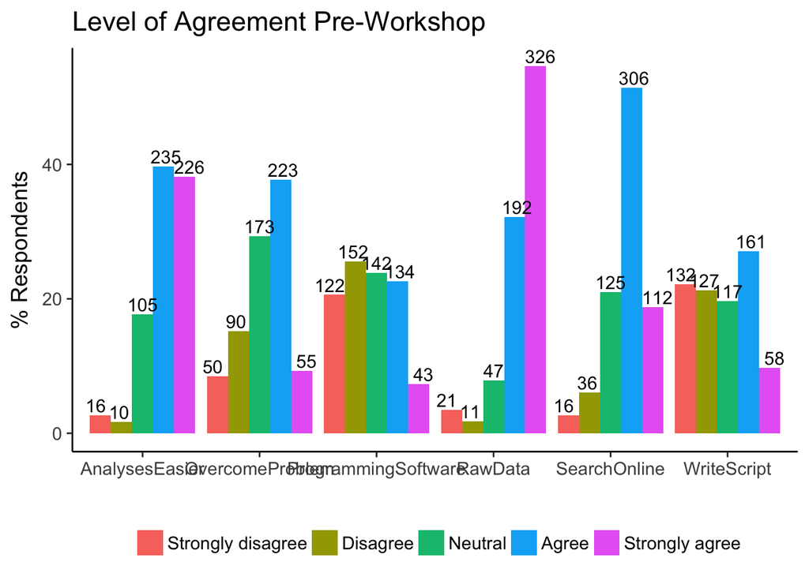

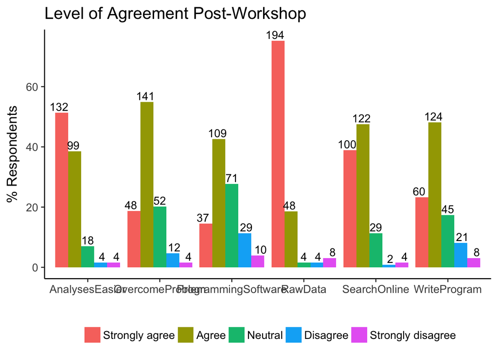

## Paired Analyses Table

| skill | mean_pre_feeling | sd_pre_feeling | mean_post_feeling | sd_post_feeling | n_pre | n_post | p.value |
| --- | --- | --- | --- | --- | --- | --- | --- |
| AnalysesEasier | 4.104167 | 0.9139077 | 4.377778 | 0.7713786 | 144 | 135 | 0.0031887 |
| OvercomeProblem | 3.181818 | 1.0183967 | 3.807407 | 0.8149379 | 143 | 135 | 0.0000000 |
| ProgrammingSoftware | 2.542254 | 1.2182026 | 3.533333 | 0.9910043 | 142 | 135 | 0.0000000 |
| RawData | 4.416667 | 0.9274373 | 4.622222 | 0.8540218 | 144 | 135 | 0.0419499 |
| SearchOnline | 3.805556 | 0.8712805 | 4.281481 | 0.7595349 | 144 | 135 | 0.0000002 |

# Demographic Data for U.S. Participants

With what gender do you most identify?

| Gender Identity | n | % |
| --- | --- | --- |
| Female | 126 | 60 |
| Male | 82 | 39 |
| Transgender female | 1 | 0 |

### Data Carpentry (Post-Workshop)

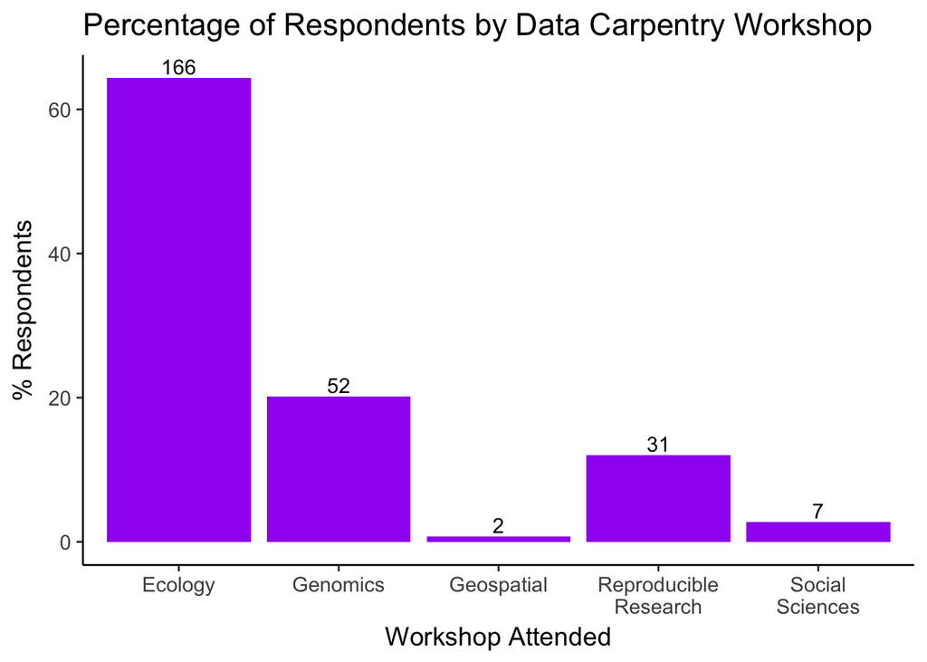

# Perception of Workshop Atmosphere

I felt comfortbale learning in this workshop environment.

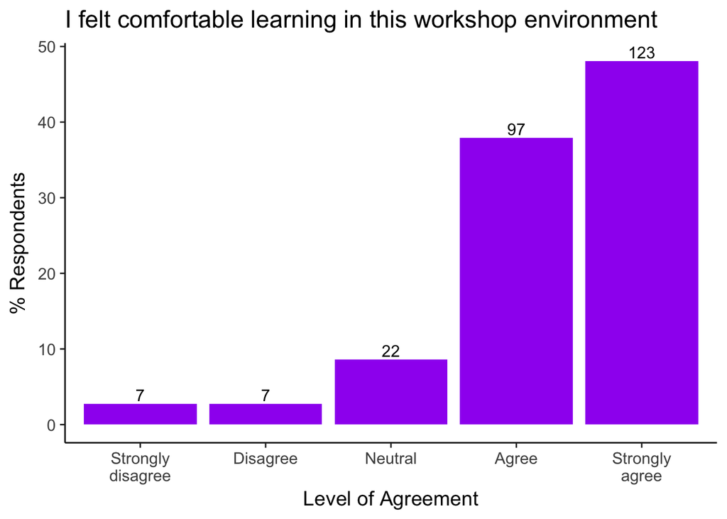

I can immediately apply what I learned at this workshop

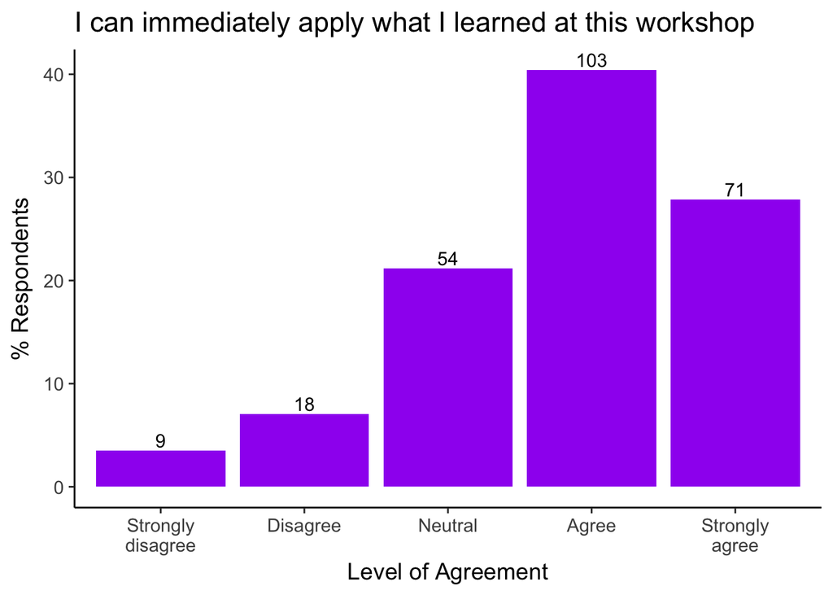

Were there any accessibility issues that affected your ability to participate in this workshop?

| Accessibility Issues | n | % |
| --- | --- | --- |
| No | 225 | 88.2 |
| Yes | 30 | 11.8 |

# Perception of Instructors and Helpers

Respondents were asked to rate their level of agreement with several statements regarding their instructor’s knowledge, instructional method, and enthusiasm. Their responses are in the figure below, and axis labels corresponding to the statements are as follows:

- **InstructorsKnowledge**: The instructors were knowledgeable about the material being taught.
- **InstructorsEnthusiastic**: The instructors were enthusiastic about the workshop.
- **InstructorsComfortable**: I felt comfortable interacting with the instructors.
- **InstructorsClear**: I was able to get clear answers to my questions from the instructors.

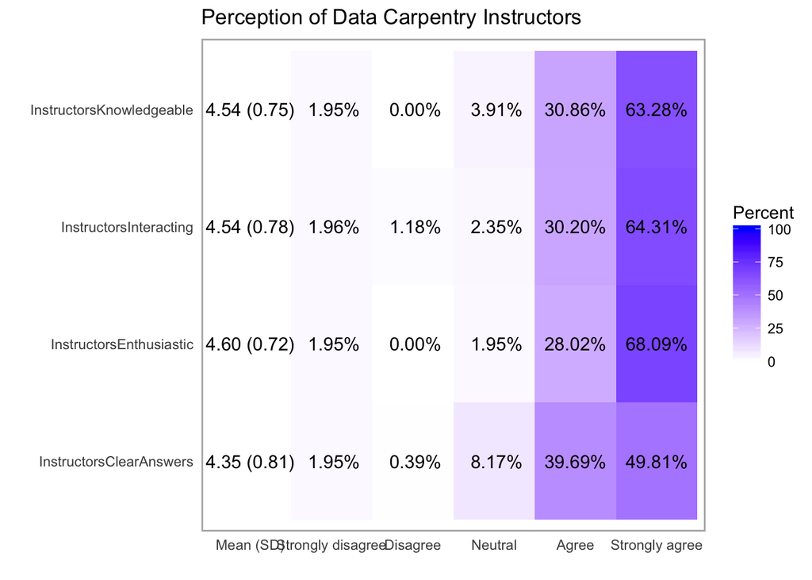

# Recommending Data Carpentry Workshops

Learners were asked how likely they are to recommend this workshop to a friend or colleague using the [Net Promoter Score](https://en.wikipedia.org/wiki/Net_Promoter). The scoring for this question based on a 0 to 100 scale. Respondents scoring from 0 to 64 are labeled *Detractors*, and are believed to be less likely to recommend a workshop. Those who respond with a score of 85 to 100 are called *Promoters*, and are considered likely to recommend a workshop. Respondents between 65 and 84 are labeled *Passives*, and their behavior falls in the middle of Promoters and Detractors.

| Promoter Score | n | % |
| --- | --- | --- |
| Detractor | 14 | 5.511811 |
| Passive | 49 | 19.291339 |
| Promoter | 191 | 75.196850 |

### Software Carpentry (Pre-Workshop)

# Pre-Workshop Survey Demographics: Workshop Location

In Software Carpentry’s pre-workshop survey, respondents are asked whether or not their workshop takes place in the United States.

| SWC Workshops in US | n | % |
| --- | --- | --- |
| Yes | 5158 | 43.7 |
| No | 3957 | 33.6 |

# Pre-Workshop Survey Demographics: Domain of Research/Work/Study

| Software Carpentry’s Respondents by Discipline | n | % |
| --- | --- | --- |
| Life Sciences (Genetics, genomics, bioinformatics ) | 2254 | 21.4 |
| Life Science - Organismal/systems (ecology, botany, zoology, microbiology, neuroscience) | 2225 | 21.1 |
| Mathematics/statistics | 761 | 7.2 |
| Physics | 660 | 6.3 |
| Planetary sciences (geology, climatology, oceanography, etc.) | 645 | 6.1 |
| Medicine and/or Pharmacy | 554 | 5.2 |
| Civil, mechanical, chemical, or nuclear engineering | 540 | 5.1 |
| Social sciences | 463 | 4.4 |
| Chemistry | 446 | 4.2 |
| Economics/business | 384 | 3.6 |
| Psychology | 364 | 3.4 |
| Library and information science | 326 | 3.1 |
| High performance computing | 311 | 2.9 |
| Humanities | 268 | 2.5 |
| Education | 210 | 2.0 |
| Space sciences | 142 | 1.3 |

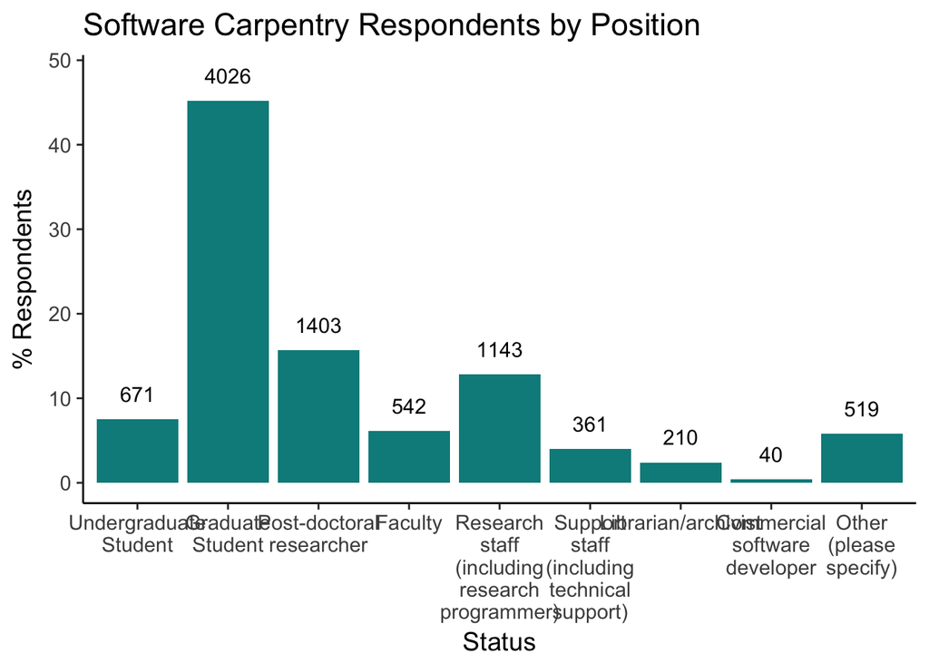

### Software Carpentry (Post-Workshop)

Learners were asked to rate their level of agreement on a scale of 1 (Strongly Disagree) to 5 (Strongly Agree) for the following statements regarding the atmosphere and content of the workshop they attended:

- **Atmosphere**: The overall atmosphere of the workshop was welcoming.
- **Material**: The material presented matched the workshop description.
- **Recommend**: I would recommend this workshop to a friend/colleague.
- **Skills**: I learned skills that I will be able to use in my research/work.
- **Worth**: The workshop was worth my time.
- **Information**: The amount of information covered at the workshop was reasonable for allotted time.

The following Likert chart is an analysis of learner responses to the statements above.

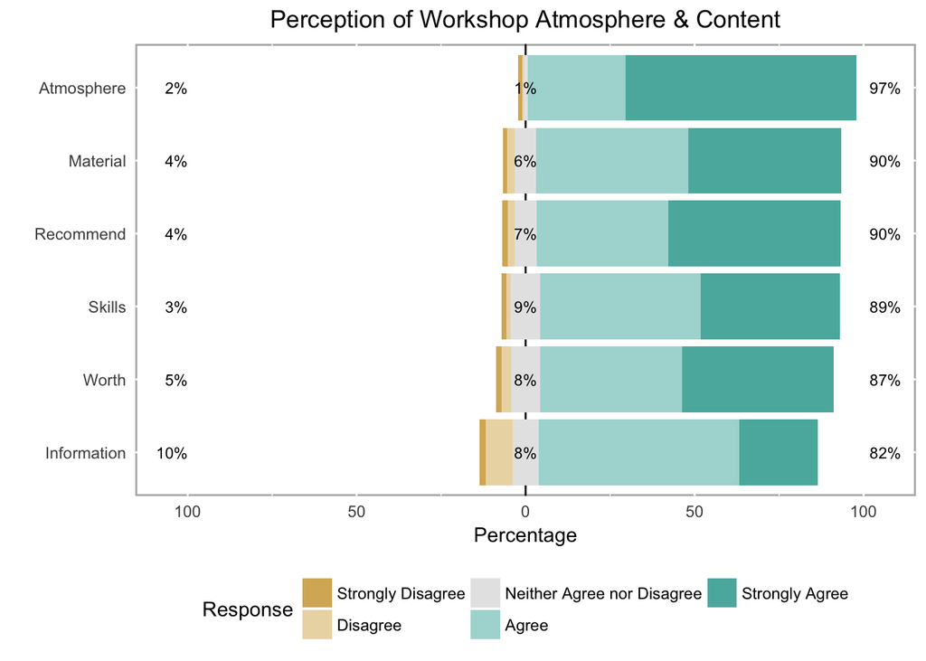

# Respondent Perception of Workshop Content and Atmosphere

[output not shown]

| Balance: Lecture to Hands-On Work | n | % |
| --- | --- | --- |
| Too much lecture | 59 | 1.7 |
| Slightly too much lecture | 354 | 10.3 |
| Balanced (lecture/hands-on) | 2773 | 81.0 |
| Slightly too much hands-on | 204 | 6.0 |
| Too much hands-on | 35 | 1.0 |

# Respondent Perception of Workshop Instructors and Helpers

Respondents were asked to rate how they felt instructors and helpers worked as a team based on the following criteria:

- **Considerate**: Instructors/Helpers were considerate.
- **Enthusiastic**: Instructors/Helpers were enthusiastic.
- **Communicators**: Instructors/Helpers were good communicators.
- **Clear.Answers**: Instructors/Helpers gave clear answers to your questions.

The two Likert plots below provide an analysis of respondent answers.

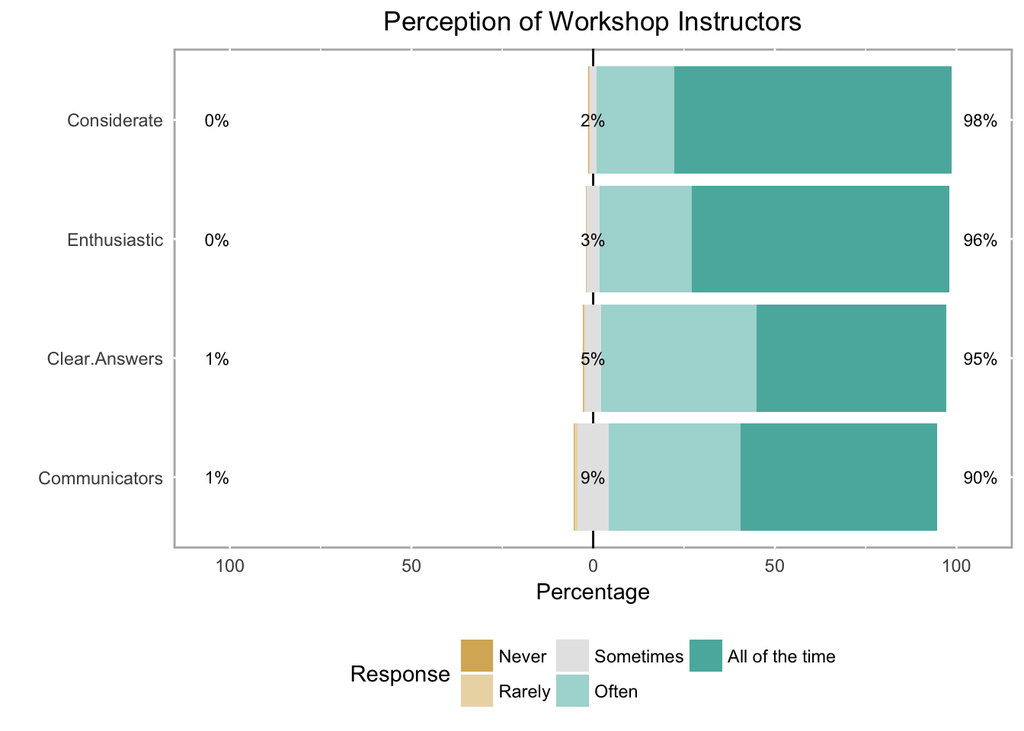

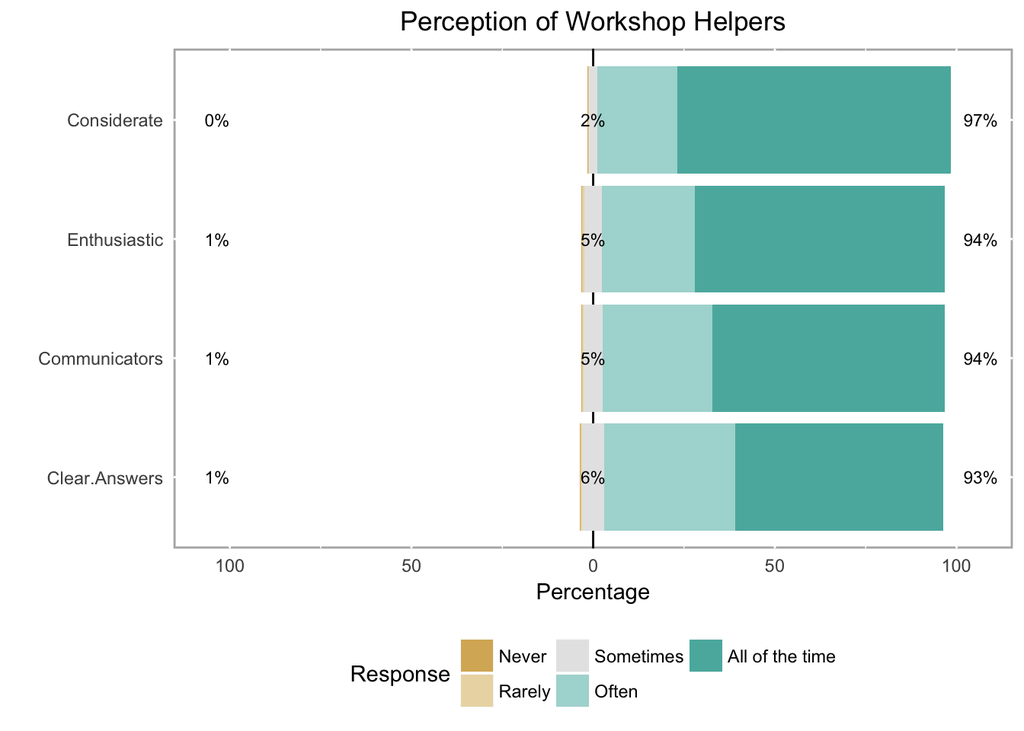

Were there enough helpers at the workshop?

94.1% of respondents felt there were enough helpers in the workshop they attended.

# How much information was new?

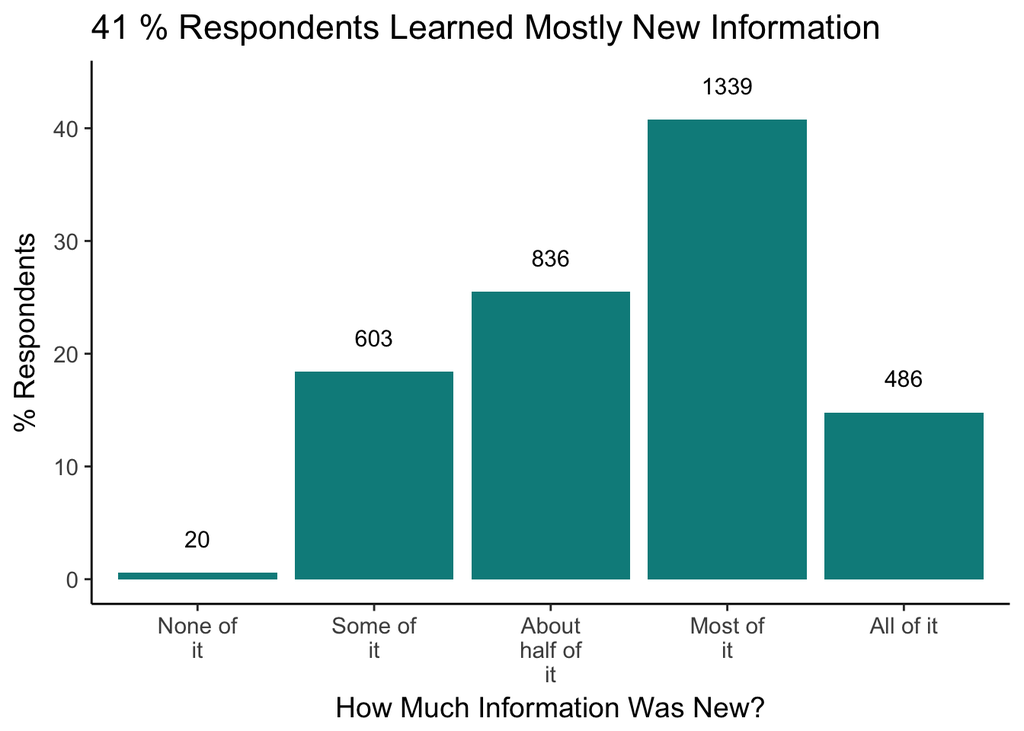

# Experience with tools pre-workshop

Before the workshop tell us about your experience with these topics.

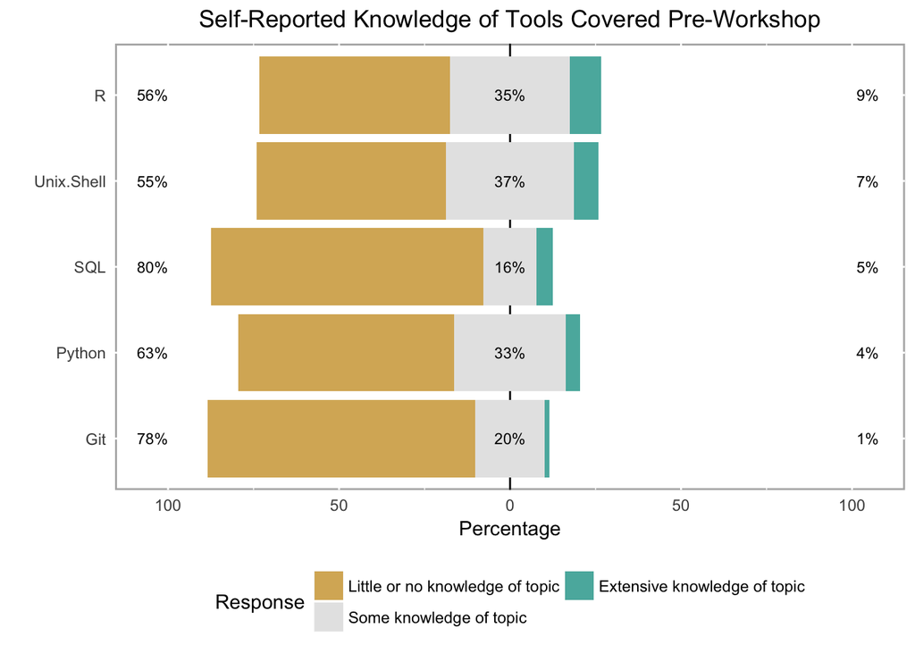

# How intimidating were the tools before the workshop?

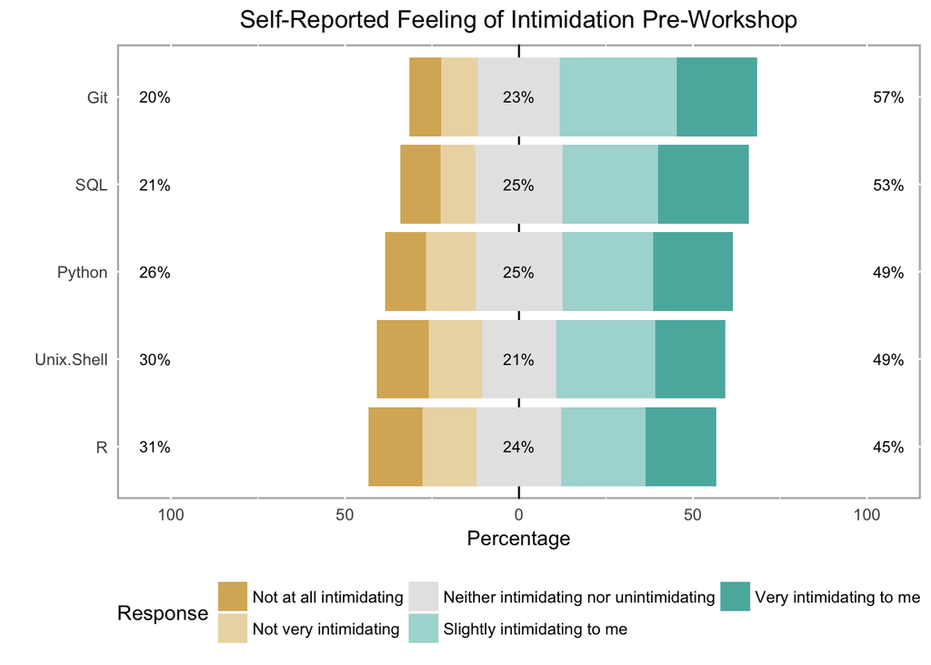

# Self-Reported Knowledge Increase

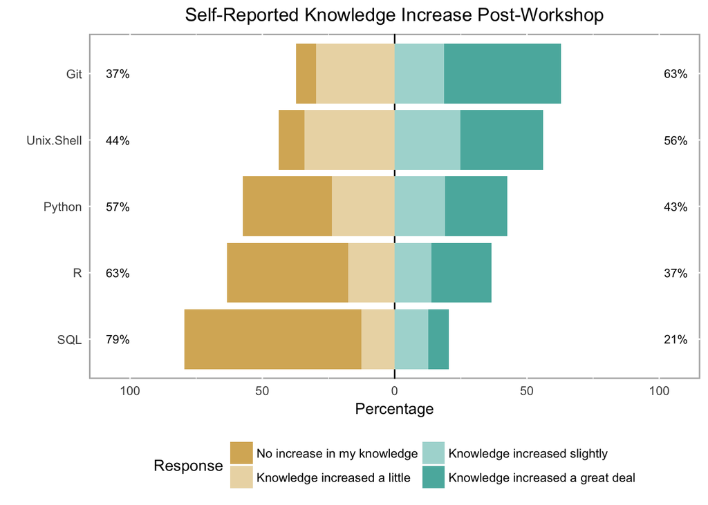

# Self-Reported Knowledge Increase: Pre/Post Comparison

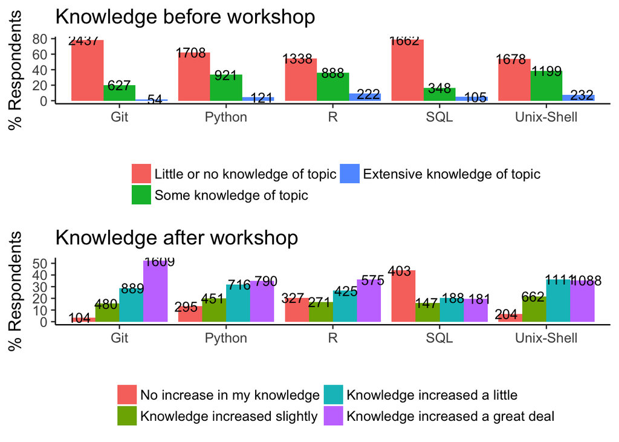

# Motivation to Learn Post-Workshop

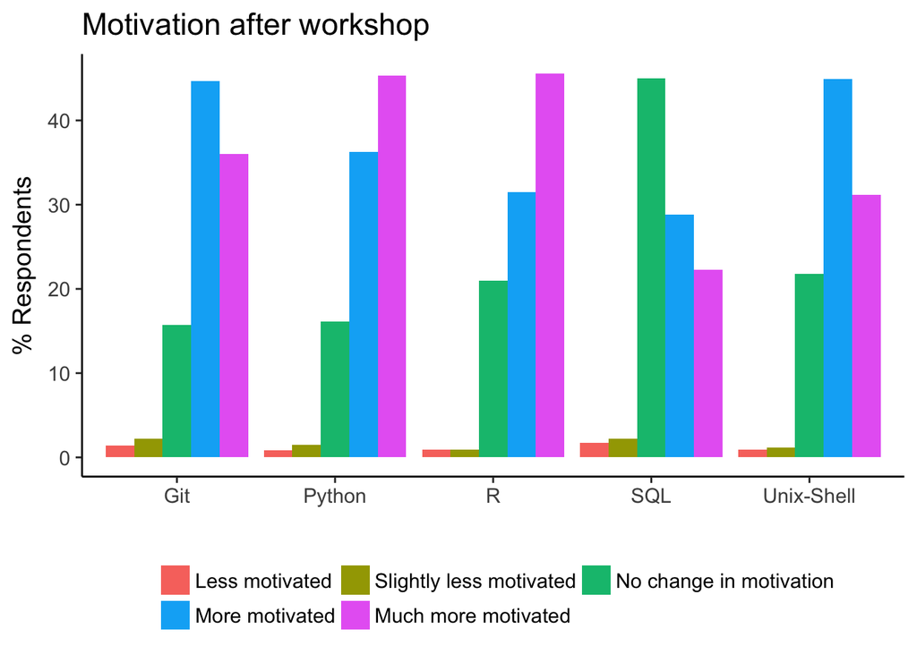

# Respondent Ability to Perform Computing Tasks

Motivation is important, but being confident in your ability to complete specific computing tasks is an equally important goal of Software Carpentry. The grid below shows respondents’ self-reported ability to complete tasks including:

- Using pipes to connect shell commands
- Writing a ‘for loop’ to automate tasks
- Initializing a repository with git
- Writing a function
- Importing a library or package in R or Python
- Writing a unit test in Python or R
- Writing an SQL query

It also provides their self-reported level of confidence in being able to complete the tasks above after completing the workshop.

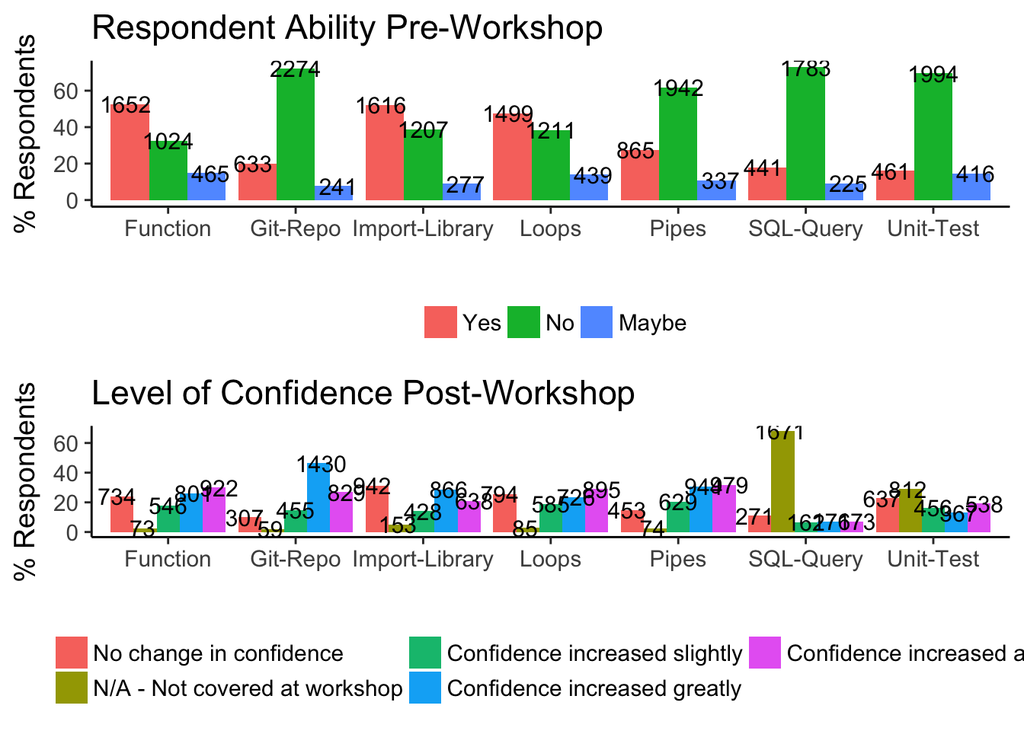